Skip to contents

# Animation

Source: [`vignettes/articles/animation.qmd`](https://github.com/r-vellum/vellumplot/blob/main/vignettes/articles/animation.qmd)

An animated plot is a sequence of still plots played in quick succession. In vellumplot the stills are **keyframes** — one compiled plot per *state* — and the frames between them are **tweened**: their marks are interpolated so a point glides from where it sits in one state to where it sits in the next.

This is *non-reactive* keyframe animation. The states are decided up front (the levels of a column), and the scales are trained **once over every state and then frozen**. Nothing retrains between frames: the axis breaks, the colour ramp and the size legend are the same in every frame, so the eye can read motion against a fixed backdrop. Animation is not a live/reactive runtime — it is a fixed set of states compiled ahead of time.

## The pipeline

Four verbs, added to any plot:

- `transition_states(states)` — marks the column whose levels are the states.
- `ease_aes(ease)` — chooses the easing (how the interpolation accelerates).
- `animate(nframes, fps)` — compiles the keyframes and returns a `vellum_animation`.
- `anim_save(file, animation)` — tweens and encodes the frames to a file.

```r
library(gapminder)

vplot(gapminder) |>
  mark_point(x = gdpPercap, y = lifeExp, size = pop, color = continent) |>
  scale_x_continuous(trans = "log10") |>
  transition_states(year, transition_length = 2, state_length = 1) |>
  ease_aes("cubic-in-out") |>
  animate(nframes = 100, fps = 25) |>
  (\(a) anim_save("gapminder.gif", a))()
```

The output format follows the file extension: `.gif` for a looping animated GIF (universally viewable), `.png` or `.apng` for an animated PNG (APNG — lossless, with transparency), or `.svg` for an animated SVG. The tween, the parallel render across CPU cores, and the streaming encode all happen in one pass in vellum’s Rust backend.

### Animated SVG, and choosing a format

`.svg` writes a single **animated SVG**: every frame is emitted as vector markup and shown in turn by a CSS step animation. Two things make it worth reaching for. It is **resolution-independent** — the same file is crisp in a slide, on a retina screen, and in print, which no raster format is. And it honours **`prefers-reduced-motion`**: a reader who has asked their system not to animate is shown one still frame, with no extra work from you – the last frame when the animation ends on its final state (a reveal, `transition_time()`, a non-looping `transition_states()`), otherwise the first. Each animated SVG namespaces its CSS, so several can share one HTML page.

The trade-off is size. Because every frame is emitted in full, an animated SVG grows with the number of marks times the number of frames, where a GIF does not. So it wins clearly on **line art** — a handful of moving marks, the common explanatory case — and loses on a **dense scatter**, where a raster format is the right answer. Choose by mark count, not by preference; `anim_save()` says so when a `.svg` scene is dense enough that a raster format would likely be smaller. Serve it gzipped (`.svgz`, or a web server with compression) to shrink it several-fold.

```r
p |> animate() |> (\(a) anim_save("draw.svg", a))()
```

### Video and WebP

There is no video or animated WebP encoder among vellum’s dependencies, so `anim_save()` does not write `.mp4`, `.webm` or `.webp`. Given one of those names it stops and tells you what to do instead: save an APNG or a GIF and convert it.

```bash
ffmpeg -i anim.png -pix_fmt yuv420p anim.mp4
```

```r
magick::image_write(magick::image_read("anim.gif"), "anim.webp")
```

## A bar chart race

The viral “bar chart race” needs no special API — it is an ordinary `transition_states()` animation over long-format data. Because each bar is keyed by its category, the tween slides bars past one another as their ranks change between states, and the frozen scales keep the value axis from jumping.

```r
set.seed(1)
cats <- c("A", "B", "C", "D", "E")
race <- do.call(rbind, lapply(2000:2006, function(y)
  data.frame(year = y, cat = cats,
             value = pmax(1, runif(5, 1, 10) + (y - 2000) * c(2.5, 1, 0.4, 3, 1.6)))))

vplot(race) |>
  mark_bar(x = cat, y = value, fill = cat) |>
  coord_flip() |>
  transition_states(year, transition_length = 2, state_length = 1) |>
  labs(title = "Bar chart race") |>
  animate(nframes = 60, fps = 12) |>
  (\(a) anim_save("race.gif", a))()
```

`coord_flip()` makes the bars horizontal (the familiar racing layout); rank the categories within each year first if you want them sorted top-to-bottom.

## What a keyframe looks like

`animate()` compiles one keyframe per state. `anim_frame()` saves any single frame as a still PNG, SVG or PDF; here is the first frame of an `mtcars`-by-cylinder animation, the first state. Each car is its own mark, keyed by `data_id` (see Which mark becomes which):

```r
cars <- transform(mtcars, car = rownames(mtcars))

a <- vplot(cars) |>
  mark_point(x = wt, y = mpg, size = hp, color = factor(cyl), data_id = car) |>
  transition_states(cyl) |>
  ease_aes("cubic-in-out") |>
  animate(nframes = 60, fps = 20)
```

```r
anim_frame("keyframe.png", a, frame = 1)
```

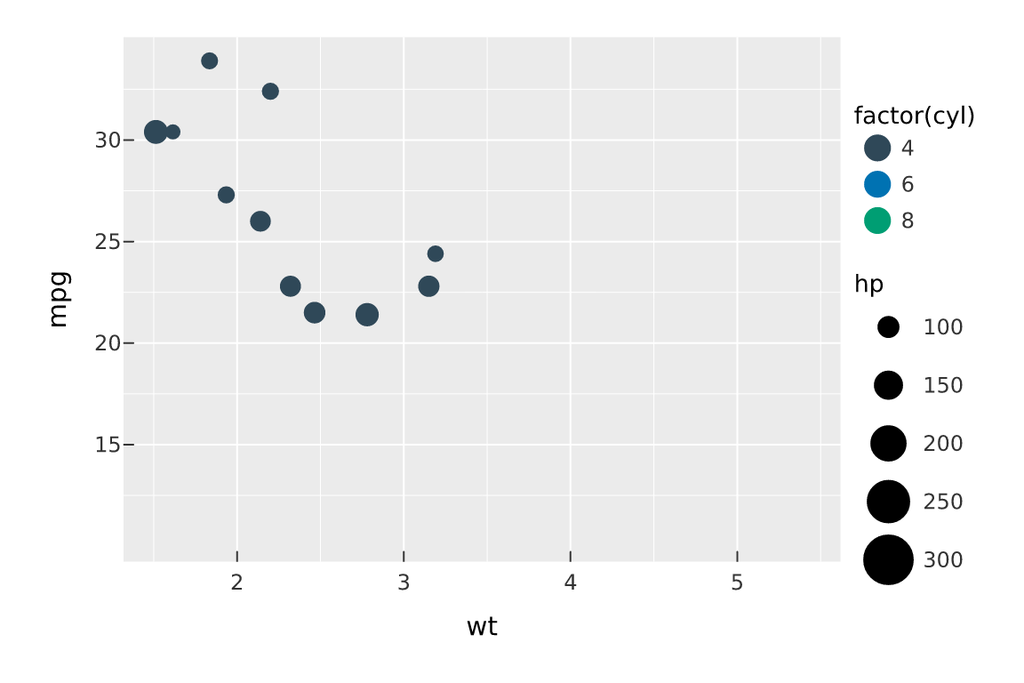

The keyframes themselves are ordinary vellum scenes, in `a@scenes` (one per state), so you can also inspect one with vellum’s tools.

## Posters and stills

`anim_frame(filename, animation, frame)` is the way to get a poster, a thumbnail, or the moment to put in print. The frame is drawn exactly as it appears in the animation, with the same frozen scales, tween and frame variables, so the poster matches the animation it stands for. A static plot built separately from one state would train its scales on that state alone.

Frames are numbered as in the saved file, pauses and rewind included (see Timing). Leave `frame` out to get the frame a reader who asks for reduced motion sees: the final frame when the animation ends on its last state, otherwise the first.

```r
anim_frame("poster.png", a)              # the reduced-motion frame
anim_frame("middle.svg", a, frame = 25)  # a mid-transition frame, as vector
```

## Frozen scales — the non-reactive guardrail

Because the scales are trained once over the pooled states, the domain is the *union* across every state. A point that is extreme in one state and typical in another keeps a stable position reference throughout: the axes never jump. This is the observable proof that the animation stayed non-reactive — compare the axis breaks of any two keyframes and they are identical, even though the two states’ data cover very different ranges.

Per-state *statistics* still recompute (a smooth is refit per state, a bin count re-tallied), but no scale *domain* retrains. Retraining a scale in response to the data of the moment would be a reactive runtime, which vellumplot is deliberately not.

## Easing

`ease_aes()` shapes how the interpolation fraction moves through each transition. `"linear"` is a constant rate; a family name with a direction suffix eases in, out, or both:

- families: `quad`, `cubic`, `quart`, `quint`, `sine`, `expo`, `circ`, `back`, `elastic`, `bounce`
- directions: `-in`, `-out`, `-in-out`

`"cubic-in-out"` — slow start, quick middle, slow finish — reads as the most natural motion for most plots.

The easing can differ per aesthetic. `ease` sets the default, and `position`, `color` (or `colour`), `size` and `alpha` each override it for one class of property:

```r
# Bars settle into place gently while the fill crossfades at a steady rate.
ease_aes("cubic-in-out", color = "linear")
```

`position` covers x and y together (and every other coordinate, such as bar widths and path vertices); it also decides when discrete attributes switch. `alpha` covers the fade of marks entering and leaving.

## What tweens, and what does not

Between two keyframes, an element’s **position**, **size**, **alpha**, and **colour** interpolate — colour perceptually, in Oklab, so a hue transition stays vivid instead of passing through grey. Discrete attributes (a marker shape, a line type, a text label) do not interpolate continuously; they snap at the midpoint.

### Which mark becomes which

Marks tween by **identity**, as gganimate matches by group. A mark of one state moves into the mark that is the same thing in the next state, however the rows are ordered. A mark’s identity is:

1. its `data_id`, when the layer has one (`mark_point(..., data_id = country)`);
2. otherwise its group: the `group` aesthetic if mapped, else the combination of the layer’s discrete mapped aesthetics (`color`, `fill`, `shape`, a discrete `x`, and so on), so a bar race’s bars keep their colours as they slide between ranks;
3. and within a group, the order of its rows.

A line, path or area is one mark per series and is matched by its group.

Row order is the last resort. It is enough when each group has one mark per state, but when a group has several rows and changes size between states, rows pair up by position and a point may jump to another row’s place. `animate()` tells you once when that can happen and suggests a `data_id`; give the layer one (or a `group`) when its rows are individual observations.

### Entering, leaving and morphing

A mark found in only one of two adjacent states **enters** (fades in) or **exits** (fades out) on the alpha easing: points, bars, tiles, labels, lines and areas alike. A point whose colour group changes slides to its new place while its colour blends. A line, path or area whose number of points changes **morphs** from one outline into the other.

What cannot move switches whole halfway through the transition: decoration without an identity that comes and goes, or a line that cannot be morphed (a line broken by missing values, say). `animate()` warns once when that will happen and names the states.

Give each transition enough frames to be seen: `nframes` is spread over all the states, so 40 states in 80 frames leave two frames per state and nothing visibly moves.

### Missing values

Rows with a missing position or size draw nothing, as in a static plot, and `animate()` says so once per layer for the whole animation (“Removed n rows containing missing values”). The count includes rows that are in no frame at all, such as those with a missing state.

## Faceted animations

A faceted plot animates panel by panel. Every panel of the whole data is drawn in every frame: a state with no rows for a panel leaves that panel empty rather than changing the layout. A mark’s identity includes its panel, so a mark never slides from one panel into another. A row whose facet value changes between states fades out of one panel and into the other.

```r
af <- vplot(cars) |>
  mark_point(x = wt, y = mpg, color = factor(gear), data_id = car) |>
  facet_wrap(~am, labeller = label_both) |>
  transition_states(cyl) |>
  animate(nframes = 30, fps = 10)
```

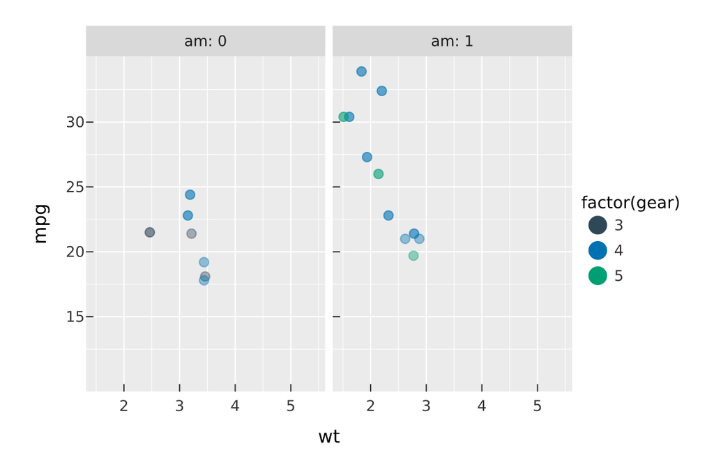

The scales are frozen across frames, so per-panel scales can’t be honoured: `facet_wrap(scales = "free")` (or `"free_x"`, `"free_y"`) and any independent scale in `resolve_scale()` (position, colour or any other) stop `animate()` with an error that says to use shared scales. `transition_reveal()` works with facets too.

## Frame variables

Titles can count along with the animation. A title, subtitle or caption set with `labs()` may embed frame variables in braces, glue-style, as in gganimate. Each `{...}` is an R expression evaluated for every frame, not only at the keyframes, so a `{frame_time}` title counts through the in-between times while the marks move. Write `{{` and `}}` for literal braces.

- every transition: `frame`, `nframes`, `progress` (`frame / nframes`);
- `transition_states()`: `closest_state`, `previous_state`, `next_state` and `transitioning` (`TRUE` while moving);
- `transition_time()`: `frame_time`, the time the frame has reached;
- `transition_reveal()`: `frame_along`, the `along` value revealed so far.

```r
vplot(gapminder) |>
  mark_point(x = gdpPercap, y = lifeExp, size = pop, color = continent) |>
  scale_x_continuous(trans = "log10") |>
  transition_time(year) |>
  labs(title = "Year: {round(frame_time)}") |>
  animate(nframes = 100, fps = 25)
```

A `mark_text()` label can use the same variables. The label is placed (and moves) like any mark, and only its string changes per frame, so a large year behind a bubble chart is one more layer:

```r
mark_text(
  data = data.frame(x = 3000, y = 40), x = x, y = y,
  label = "{round(frame_time)}", size = 60, color = "grey85"
)
```

Repelled and rich-text labels are not templated. An ordinary data label whose string differs between two states takes the nearer state’s string, switching halfway through.

## Continuous time

`transition_time()` is the continuous-time sibling of `transition_states()`: it treats the column as a time and allocates frames **in proportion to each time gap**, so the animation runs at a constant rate even when the times are unevenly spaced. Time flows once — no pause on a state, no wrap.

```r
vplot(gapminder) |>
  mark_point(x = gdpPercap, y = lifeExp, size = pop, color = continent) |>
  scale_x_continuous(trans = "log10") |>
  transition_time(year) |>
  animate(nframes = 100, fps = 25) |>
  (\(a) anim_save("gapminder.gif", a))()
```

The time may be numeric, `Date` or `POSIXct`. Dates and date-times are spaced by their day or second gaps, and `{frame_time}` keeps their class (and time zone), so `labs(title = "{format(frame_time, '%d %b %Y')}")` works.

## Reveal

`transition_reveal(along)` is a different kind of animation: instead of tweening between states, it **reveals the data along `along`**, as gganimate does — the classic “line draws itself”. Each frame shows the rows whose `along` value has been reached. Points appear as they are reached; a line, path, area, ribbon or step grows through its rows with an interpolated leading point, each series toward its own next row. The scales are frozen over the whole data, and the background, grid, axes and legends are drawn whole throughout.

```r
set.seed(1)
walk <- data.frame(t = 1:60, y = cumsum(rnorm(60)))

ar <- vplot(walk) |>
  mark_line(x = t, y = y) |>
  mark_point(x = t, y = y) |>
  transition_reveal(t) |>
  labs(title = "t = {round(frame_along)}") |>
  animate(nframes = 30, fps = 10)
```

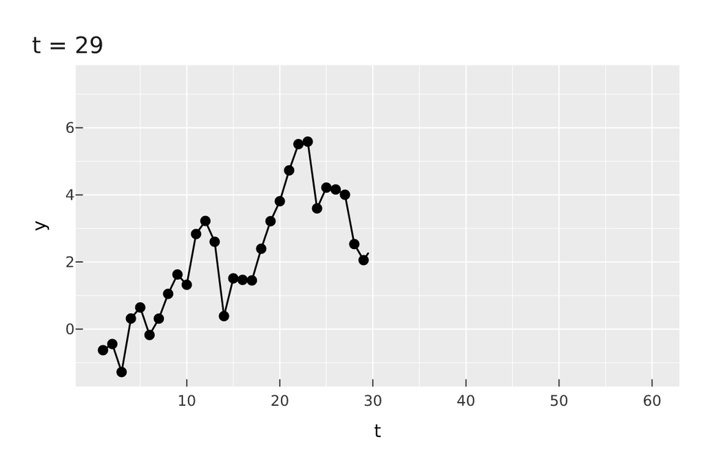

`along` may be numeric, `Date` or `POSIXct`, and needn’t be the x axis: a spiral revealed by angle, or a `coord_flip()` series, unrolls in data order. Each frame is its own keyframe, so `animate()` compiles `nframes` scenes.

## Timing

`transition_length` and `state_length` are *relative* durations: how long the moving segments last versus the held pauses on each state. `nframes` is the total frame count and `fps` the playback rate, so the animation runs for `nframes / fps` seconds. `wrap = TRUE` (the default) loops the last state back to the first.

`animate()` also takes gganimate’s `start_pause`, `end_pause` and `rewind`. The pauses hold the first and last frame for that many frames, and `rewind = TRUE` plays the animation back to the start so the loop doesn’t cut. They come out of `nframes`: `animate(nframes = 100, end_pause = 20)` moves for 80 frames and rests on the final picture for 20. Every output follows them: `anim_save()` to GIF, APNG or SVG, the frame numbers of `anim_frame()`, and the frame scrubber of an animated vellumwidget.

```r
p |>
  transition_states(year, wrap = FALSE) |>
  animate(nframes = 100, fps = 25, end_pause = 25) # hold the end for a second
```